Rugby has faced many controversies and alleged conspiracies. Was rugby [complicit](https://en.wikipedia.org/wiki/1981_South_Africa_rugby_union_tour) in [apartheid](http://www.teara.govt.nz/en/photograph/26666/all-white-all-blacks-1928)? Whatever happened to [Keith Murdoch](http://www.smh.com.au/rugby-union/union-news/the-murdoch-myth-all-blacks-legend-lives-life-of-a-recluse-after-infamous-punch-20111020-1mb2p.html)? Did [Suzie the waitress](https://en.wikipedia.org/wiki/1995_Rugby_World_Cup_Final) really stoop so low? One ongoing controversy concerns the extent to which international rugby teams “poach” players from other countries. Most of the heat is usually directed toward New Zealand, who are accused of being particularly predatory in their foreign recruitment.[^1] Until now, this debate among the international rugby public and media has largely relied on casual observations and anecdotes rather than evidence.[^2]

To bring sanity to the discussion, I constructed a dataset of the birth place and playing statistics of every international rugby player to have played for the major test nations.[^3] In the analysis below, I focus on players making their debut in the professional era (post 1996) for the 10 “major” nations and define a foreign player as someone who was not born in the country for whom they played.[^4] You can find out more about the data and maybe help me fill out a couple missing datapoints below.

The following table presents an overview of players to debut for each country in the professional era.[^5] On average, 202 players debuted for each country since 1996, which ranged from 155 for Ireland to 310 for Argentina.

#### Player Debuts in the Professional Era (1996 - 2016)

|  | **Argentina** | **Australia** | **England** | **France** | **Ireland** | **Italy** | **New Zealand** | **Scotland** | **South Africa** | **Wales** |
| --- | --- | --- | --- | --- | --- | --- | --- | --- | --- | --- |
| Native | 275 | 126 | 170 | 222 | 119 | 121 | 156 | 94 | 198 | 151 |
| Foreign | 4 | 40 | 43 | 23 | 35 | 58 | 27 | 75 | 10 | 39 |
| Total | 310 | 166 | 213 | 245 | 155 | 180 | 183 | 169 | 208 | 190 |

Much of the debate about player poaching is predicated on the assumption of an increasing trend in the number of foreign born players. The graph below presents the number of foreign players making their debut in each year for the 10 major nations. It shows that, on the contrary, there is no noticeable trend in the number of foreign players. It has generally fluctuated around an average of 17 foreign-born debutants per year, with a low of 8 in 2007 and a high of 26 in 2013. There were more foreign born players in 2002, for example, than there were in 2015.

#### Foreign Born Trend

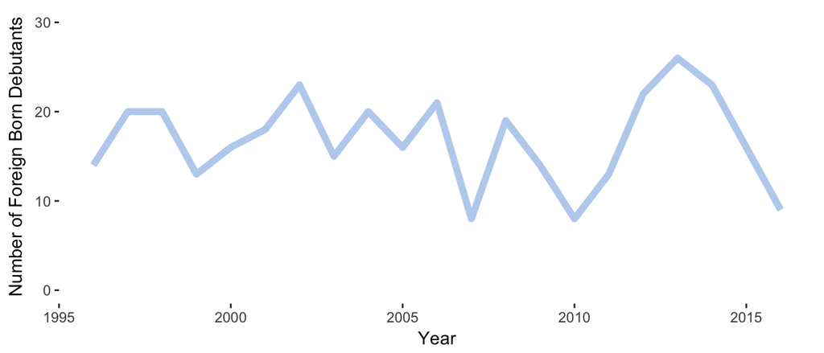

#### Foreign Born Players

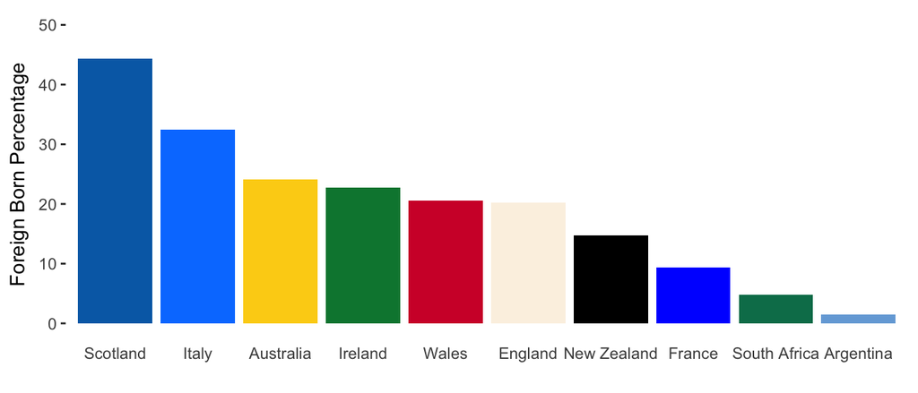

That no countries are immune to player poaching shouldn’t be surprising. International migration is a reality of the modern world, and many of the top rugby countries have large foreign born populations. The following graph compares the extent to which the foreign born composition of each rugby side is representative of the general population in that country.[^6] The red bars repeat the foreign born player percentages from the graph above while the blue bars show the percentage of each country’s population that was not born in that country. Australia has the highest proportion of its population born overseas, at 28.2%, followed by New Zealand with 23% and Ireland with 15.9%. By comparing each country’s respective blue and red bars, we see that Argentina, Australia, France, New Zealand and South Africa have rugby teams which *under*-represent the foreign-born population. Foreign-born players are *over*-represented for every other country.

#### Foreign Born Populations vs Foreign Born Players

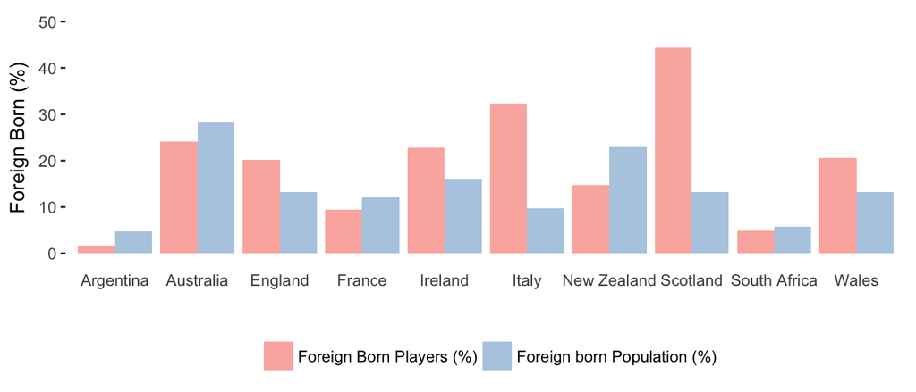

The graph below shows the top 10 “suppliers” of players to the rest of the world.[^7] 208 New Zealanders have played for another country. The next largest exporter is England with 90 players. Notable among this list are the Pacific Island countries of Samoa, Tonga and Fiji, which have contributed 53 players to the international rugby community. Notable absences include Scotland, Ireland and Wales, which have provided fewer than 7 players each to other countries, despite having had the services of 149 foreign born players combined.

#### Exports of Foreign Players

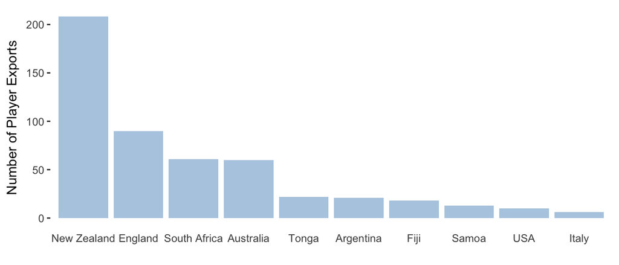

The next graph summarises the net contribution of each country to the world rugby stock. The “trade balance” is calculated by subtracting the number of “imported” players from the number of “exported” players. A positive trade balance indicates that a country contributes more players to other countries than it “poaches”. Leading the way is New Zealand, which has provided 181 more players to other countries than it has poached. On the other side of the ledger is Scotland, which has imported 68 more players than it has exported.

#### The Trade Balance

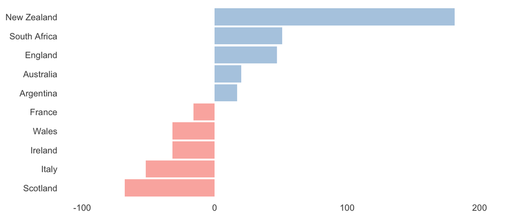

The final table addresses a common point that is often raised, which is that without imports, some countries would not compete at the same level. While it is true that importing countries get different bang for their buck from their imports, imports tend not to differ too much from their native born teammates.

#### Player Contributions

| **Team** | **Points per Native Player** | **Points per Foreign Player** | **Tries per Native Player** | **Tries per Foreign Player** | **Matches per Native Player** | **Matches per Foreign Player** |
| --- | --- | --- | --- | --- | --- | --- |
| Argentina | 20.3 | 16.2 | 2.3 | 3.2 | 12.5 | 15.2 |
| Australia | 33.4 | 28.5 | 3.8 | 4.2 | 26.6 | 28.0 |
| England | 28.8 | 12.7 | 3.0 | 1.4 | 20.5 | 13.3 |
| France | 22.2 | 12.0 | 2.1 | 2.1 | 16.5 | 21.2 |
| Ireland | 26.0 | 43.9 | 3.0 | 2.8 | 24.3 | 23.6 |
| Italy | 11.1 | 27.8 | 1.5 | 2.0 | 18.4 | 25.7 |
| New Zealand | 40.7 | 30.9 | 4.6 | 6.2 | 23.7 | 22.5 |
| Scotland | 25.2 | 16.0 | 1.9 | 2.2 | 25.4 | 19.4 |
| South Africa | 27.1 | 103.1 | 3.2 | 5.0 | 20.6 | 29.7 |
| Wales | 28.2 | 20.3 | 2.5 | 3.5 | 22.2 | 21.9 |

#### Dataset

You can scroll and search the dataset below, which contains every player from the ten major countries who debuted after 1900. You can download the full dataset [here](https://github.com/hautahi/Rugby-Wanderers/raw/master/data/1.main_data.csv), or you can view each of the individual team datasets at the following links ([Argentina](https://github.com/hautahi/Rugby-Wanderers/blob/master/data/Argentina.csv), [England](https://github.com/hautahi/Rugby-Wanderers/blob/master/data/England.csv), [Australia](https://github.com/hautahi/Rugby-Wanderers/blob/master/data/Australia.csv), [New Zealand](https://github.com/hautahi/Rugby-Wanderers/blob/master/data/NewZealand.csv), [Scotland](https://github.com/hautahi/Rugby-Wanderers/blob/master/data/Scotland.csv), [Ireland](https://github.com/hautahi/Rugby-Wanderers/blob/master/data/Ireland.csv), [Wales](https://github.com/hautahi/Rugby-Wanderers/blob/master/data/Wales.csv), [South Africa](https://github.com/hautahi/Rugby-Wanderers/blob/master/data/SouthAfrica.csv), [Japan](https://github.com/hautahi/Rugby-Wanderers/blob/master/data/Japan.csv), [Samoa](https://github.com/hautahi/Rugby-Wanderers/blob/master/data/Samoa.csv), [Fiji](https://github.com/hautahi/Rugby-Wanderers/blob/master/data/Fiji.csv), [Tonga](https://github.com/hautahi/Rugby-Wanderers/blob/master/data/Tonga.csv), [Canada](https://github.com/hautahi/Rugby-Wanderers/blob/master/data/Canada.csv), [USA](https://github.com/hautahi/Rugby-Wanderers/blob/master/data/USA.csv), [Italy](https://github.com/hautahi/Rugby-Wanderers/blob/master/data/Italy.csv), [France](https://github.com/hautahi/Rugby-Wanderers/blob/master/data/France.csv)). The Python and R programs that document both the data scraping and adjustments are available at the [Rugby Wanderers Github Repository](https://github.com/hautahi/Rugby-Wanderers).

| Name | Team | Debut | Tests | Pts | Tries | Birthplace | Birthcountry |
| --- | --- | --- | --- | --- | --- | --- | --- |
| Jack Clifford | England | 2016 | 3 | 0 | 0 | Brisbane | Australia |
| Paul Hill | England | 2016 | 1 | 0 | 0 | Aschaffenburg | Germany |
| Maro Itoje | England | 2016 | 2 | 0 | 0 | Camden | England |
| Elliot Daly | England | 2016 | 1 | 0 | 0 | Croydon | England |
| Zander Fagerson | Scotland | 2016 | 1 | 0 | 0 | Perth | Australia |
| CJ Stander | Ireland | 2016 | 3 | 0 | 0 | George | South Africa |
| Stuart McCloskey | Ireland | 2016 | 1 | 0 | 0 | Northern Ireland | Ireland |
| Josh van der Flier | Ireland | 2016 | 1 | 0 | 0 | Dublin | Ireland |
| Ultan Dillane | Ireland | 2016 | 1 | 0 | 0 | Paris | France |
| Sebastien Bezy | France | 2016 | 3 | 0 | 0 | Hauts-de-Seine | France |

[output cut: 8536 more lines]

To my knowledge, the player names and playing statistics are accurate (as at February 2016), but the birthplace information remains a work in progress. The data is especially sparse for Canada, the USA and the Pacific Island countries. I welcome any contributions and corrections. Feel free to email me (hautahikingi@gmail.com) with any help you can provide.

[^1]: Here are a few examples: [1](http://www.telegraph.co.uk/sport/rugbyunion/2361788/Ruthless-All-Blacks-harvest-fertile-Island-talent.html), [2](http://www.dailymail.co.uk/sport/rugbyunion/article-2612324/All-Blacks-remember-players-theyve-poached-Pacific-Islands.html), [3](http://www.thesundaytimes.co.uk/sto/sport/article137252.ece), [4](http://www.telegraph.co.uk/sport/rugbyunion/international/newzealand/11113937/New-Zealand-owe-a-debt-to-Samoa-that-can-only-be-repaid-with-a-full-touring-party-for-long-overdue-first-Test-visit.html), [5](http://www.theroar.com.au/2012/10/31/the-problem-with-eligibility-in-international-rugby/), [6](http://www.stuff.co.nz/sport/rugby/opinion/10132272/Gifford-Home-truths-about-Pasifika-poaching), [7](http://www.stuff.co.nz/13313/All-Blacks-accused-of-Pacific-pillage-again), and [8](http://www.thesundaytimes.co.uk/sto/sport/article137252.ece).
[^2]: The [New Zealand Herald](http://www.nzherald.co.nz/sport/news/article.cfm?c_id=4&objectid=11278276) provided a notable exception by compiling a dataset of the birthplace of every [All Black](https://en.wikipedia.org/wiki/New_Zealand_national_rugby_union_team) prior to 2014.
[^3]: I scraped the majority of my data from the superb [ESPNscrum](http://www.espnscrum.com) website, which lists statistics for every person to have played a test-match for the major rugby nations. As well as statistics like matches played, points and tries scored, there is also birth information for the majority of players. However, the birthplace information, where available, is limited to the city of birth. I therefore match the birth cities with their respective countries using the [Geopy](https://pypi.python.org/pypi/geopy) geocoding package in Python. This works well for city names that are unique to a particular country, such as Taumarunui. However, in the case of ambiguous city/country pairs, the Geopy package (to the best of my knowledge) returns the city with the highest population, which leads to errors. For example, the Geopy package attributes those players that were born in the town of Hastings, New Zealand as being born in Hastings, England. I therefore also make manual adjustments to the scraped datasets based on my own research. In the case of New Zealand, I use the dataset provided by the [New Zealand Herald](http://www.nzherald.co.nz/sport/news/article.cfm?c_id=4&objectid=11278276) for players making their test debut prior to 2015.
[^4]: This definition admittedly has some shortcomings. For example, [Ronan O’Gara](https://github.com/hautahi/Rugby-Wanderers/blob/master/data/Ireland.csv#L957), who scored 1083 points for Ireland, is considered a foreign born player because he was born in the United States, despite the fact that few would question his Irish rugby “credentials”.
[^5]: I am missing the birth information for 33 of these players, and they are not included in this table. 31 of the missing players are from Argentina, 1 from Ireland and 1 from Italy.
[^6]: I use 2015 census data retrieved from the [World Bank Data Bank](http://databank.worldbank.org/data/reports.aspx?source=2&series=SM.POP.TOTL.ZS&country=#) (Accessed on 12 March 2017). The dataset is [here](https://github.com/hautahi/Rugby-Wanderers/blob/master/data/WorldBankData/Data.csv) and details of the definitions and sources for each country can be found [here](https://github.com/hautahi/Rugby-Wanderers/blob/master/data/WorldBankData/DefinitionandSource.csv). I do not have separate migration data for the British countries. I therefore use the total United Kingdom figure of 13.2% for each of England, Scotland and Wales.
[^7]: The next two graphs use data from all countries in order to calculate player exports.